# Recommendation Engines - Individual Assignment

Recommendation Engines - Individual Assignment MBD Term 2 - Stavros Tsentemeidis 23/03/2019

## Business Case Summary

How can we improve customer experience?  
What can we do to make their life easier?  
What do they actually want when they say that they are looking for easiness and comfort?

These are some of the questions that **were**, **are** and **will** be major painpoints for any company’s strategic planning, whether it is an online platform or bricks and mortar.

The purpose of this **Recommendation Engine** project, is to propose a solution for one perspective of these questions. Our target is platforms that help people book a table at a restaurant, a bar etc. Based on their previous experiences, which are supposed to be tracked and stored through feedback forms after a complete lunch, dinner etc, we want to give them different **beer proposals** in order to be able to preorder a specific brand and kind of beer before arriving at the place booked as their next destination.

- This will help customers *personalize* and *prepare* thoroughly their experience, *taste* something *new* or make sure that their *usual* choice is waiting for them.
- Having a look at the other side also, this will make it easier for businesses to handle their *inventory*, place their *orders* according to the demand and also have a better and broadened view of *what their customers really like and dislike.* Furthermore, this kind of information can contribute to a company’s decision for a change, whether this is the style represented by the place, the actual menu or even the whole market group that they are targeting at.

### Market Analysis

The Recommendation Engine we are presenting in this case, comes with the name **Book Your Drink**. As already mentioned before, the functonality of that will be a personalized drinking experience for customers when booking a table through the client platform. One of our main clients would be **Booking.com** along with **TripAdvisor**, which is lately encorporating a *reserve a table option* for most of the places that are listed in the platform.  
Another main factor that makes our software unique is its own existence. There is no similar option around the world web for any popular booking platform.  
Regarding **competition**, while doing the respective research, it is highly notable the fact that this type of recommendation engine is nowhere to be found. There are very few places that provide the customer with an option to preorder a drink. However, even those places host these kind of booking systems in their very own website. Just think for a second though, how many times have you actually entered a bar’s website in order to book your table, not to mention yor drink. I think for most of us *Tripadvisor* or any other collective platform is the way to go. Adding into the previously mentioned statements, even though a few sites provide the booking drink option, all of them do not offer a recommendation even though they might be collecting data about clients’ preferences.

## Data Loading

- **Beer_ID**: showing the id of each unique beer brand and kind.
- **Review_Profile_Name**: showing the username of the clients that have tasted this specific beer and rated it according their liking or not.
- **Rating**: the actual rating that the user placed ranging from 0 to 5, where 0 is the worst and 5 the nest possible rating to be given.

## Data Exploration and Processing

At this stage we are checking for missing values in the column **review_profilename** and we encounter *19* missing fields which we will remove in order not to affect our analysis. Now that our dataset is clean and clear, we rearrage the columns of the matrix in order to convert it to a **realRatingMatrix**. Below can also be seen 2 summaries:

- The **Average Ratings Per User**
- The **Average Ratings Per Beer**

Based on these outputs, we are going to take different subsets of our dataframe in order to adjust different types of algorithms for our different kind of customers.

- Our *first* split will refer to users with less than **4 ratings** *(corresponds to about 65% of our customers)* and also beers with more than **13 ratings**. These users ,based on our business concept are **new** clients, for which we do not consider to have enough data to try customizing a personalized suggestion. For this case, it is decided to develop a seperate embedded algorithm that will be consisted from **POPULAR**, **UBCF** and **RANDOM** algorithms, wighted in the order that are referred to. *Popularity* in order to suggest the most demanded beer brands, *User Based Collaborative Filtering* in order to associate them with other new users and also a *random* element to help them discover new tastes.
- Our *second* will refer to users with more than **10 ratings** *(corresponds to the next 25% of our customers)* and also beers with more than **18 ratings**. These users ,based on our business concept are **existing and commited** clients, for which we do consider to have enough data to try customizing a personalized suggestion. For this case, it is decided to develop another embedded algorithm that will be consisted from **IBCF**, **UBCF** and **RANDOM** algorithms, wighted in the order that are referred to. *Item Based Collaborative Filtering* in order to correlate users among their beer , *User Based Collaborative Filtering* in order to associate them with other regular users and also a *random* element to help them discover new tastes.
- Our *third* will refer to users that are **loyal** *(corresponds to the last 10% of our customers)* to our platform. Basically, we are referring to those that have more than **25 ratings** for beers that have more than **30 ratings**. For this section of the market it is decided to use **IBCF**, **UBCF** and **RANDOM** but with a different weight distribution with regard to the regular users, as we have more data on what those customers prefer.*Item Based Collaborative Filtering* in order to correlate users among their beer, *User Based Collaborative Filtering* in order to associate them with other new users and also a *random* element to help them discover new tastes.

Further analysis of its split after the exploratory one of the dataset.

Another transformation that is taken at this stage is the **normalization** of the `beers_rating` dataset, in order for our recommendations to come out unbiased!

|  | Min. | 1st Qu. | Median | Mean | 3rd Qu. | Max. |
| --- | --- | --- | --- | --- | --- | --- |
| Average_ratings_per_user | 1 | 1 | 3 | 21.09001 | 11 | 1842 |
| Average_ratings_per_beer | 1 | 1 | 2 | 11.77208 | 5 | 977 |

## Initial Dataset

At this stage of our analysis, we want to continue with some EDA in order to have a better undestanding of the similarity in our dataset. To do so we have the following statements along with the *matrixes* and *histograms* trying to answer those statements.

### Determine how similar the first 1000 users and 100 beers are with each other for the whole dataset.

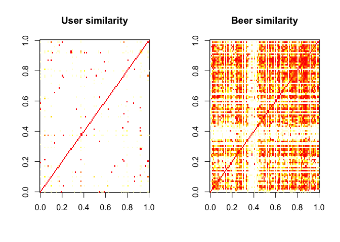

### Visualizing average rating per number of beers and per number of users

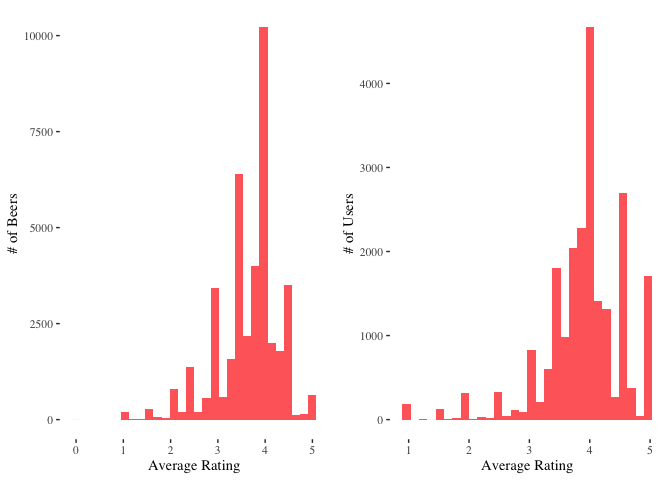

### Visualizing normalized ratings with real rating matrix of beers

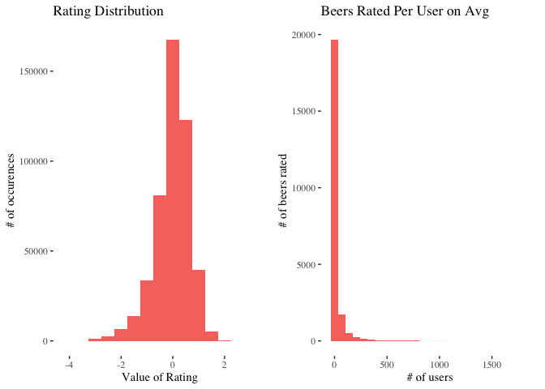

### Differences among reviewers

Do users who review more products tend to give different scores? The chart below shows that reviewers are fairly consistent despite reviewer experience. Scores tend to be about the same, although they are skewed to be positive overall with averages above 3 in all groups.

| Review Count | Average Score | Median Score | Std Deviation |
| --- | --- | --- | --- |
| (0,5] | 3.66 | 4 | 0.76 |
| (5,10] | 3.68 | 4 | 0.76 |
| (10,15] | 3.71 | 4 | 0.74 |
| (15,20] | 3.72 | 4 | 0.73 |
| (20,25] | 3.71 | 4 | 0.74 |
| (25,30] | 3.71 | 4 | 0.72 |
| (30,35] | 3.75 | 4 | 0.71 |
| (35,40] | 3.75 | 4 | 0.70 |
| (40,45] | 3.77 | 4 | 0.71 |
| (45,50] | 3.76 | 4 | 0.71 |
| (50,100] | 3.78 | 4 | 0.70 |
| (100,200] | 3.81 | 4 | 0.72 |

### Matrix inspection

Recommenderlab provides functions to inspect the data. As with most platforms with reviews, there will be many users, but the majority of users will not have reviewed most of the items (beers in this case) liste. As a result, the matrix will be sparse (in other words, lots of empty fields!).

```
## 5 x 4 sparse Matrix of class "dgCMatrix"
##             3 4 5 6
## 0110x011    . . . .
## 01Ryan10    . . . .
## 03SVTCobra  . . . .
## 04101Brewer . . . .
## 05Harley    . . . .
```

### Determine how similar the first 1000 users and 100 beers are with each other for the **REGULAR** Customers.

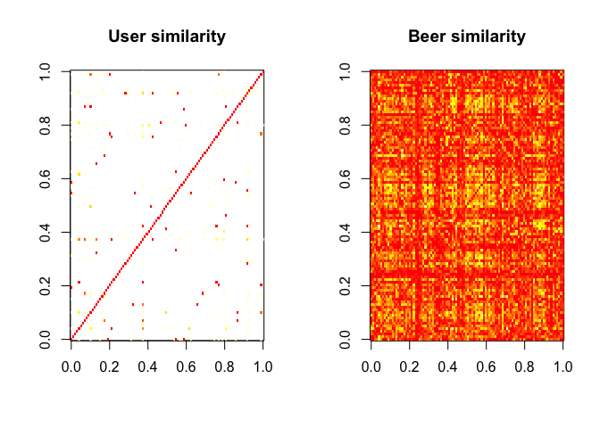

### Visualizing average rating per number of beers and per number of users

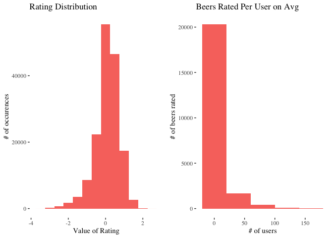

### Determine how similar the first 1000 users and 100 beers are with each other for the **NEW** Customers.

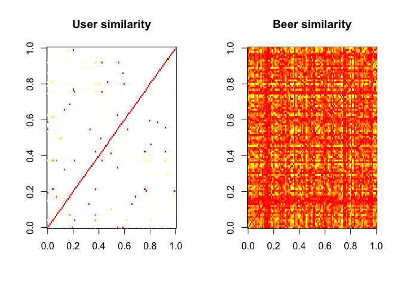

### Visualizing average rating per number of beers and per number of users

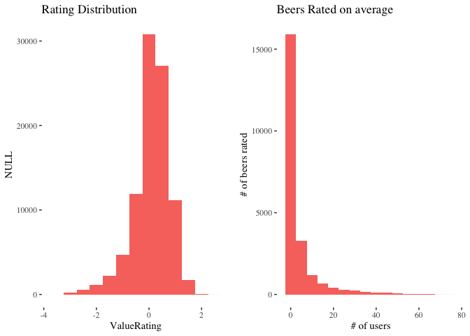

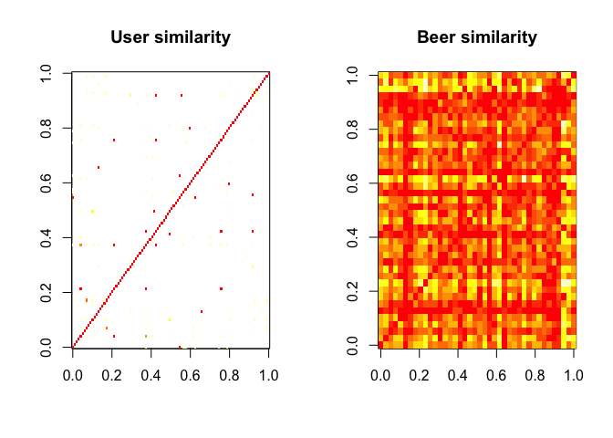

### Visualizing average rating per number of beers and per number of users

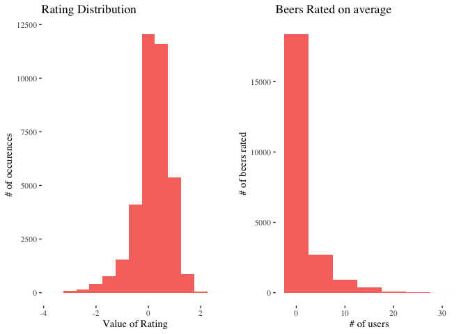

## Data Preparation for Evaluation

The next step for the dataset, is to split it using the **evaluationScheme** function. By doing that we acquire the following **train**, **test** *known* and *unknown* sets, in order to continue our analysis and evaluation of the algorithms.

#### Regular Customers Split

```
## 20241 x 5231 rating matrix of class 'realRatingMatrix' with 342105 ratings.
## Normalized using center on rows.
```

```
## 2256 x 5231 rating matrix of class 'realRatingMatrix' with 0 ratings.
```

#### New Customers Split

```
## 20241 x 227 rating matrix of class 'realRatingMatrix' with 82963 ratings.
## Normalized using center on rows.
```

```
## 2256 x 227 rating matrix of class 'realRatingMatrix' with 0 ratings.
```

#### Loyal Customers Split

```
## 20241 x 65 rating matrix of class 'realRatingMatrix' with 33128 ratings.
## Normalized using center on rows.
```

```
## 2256 x 65 rating matrix of class 'realRatingMatrix' with 0 ratings.
```

Another split that is decided to be done for some algorithms is taking the 80% as train and the 20% left as test, but as realRatingMatrix.

## Pipeline - Algorithm Selection

After making the necessary preparation and splits, it is time to define the procedure and the algorithms we are going to follow for each specific subset of our customers.

### New Customers

| Beer_ID | Beer_Name |
| --- | --- |
| 17 | Guiness |
| 30 | Blue Moon |
| 33 | Boston Lager |
| 34 | Heineken |
| 59 | Corona |
| 61 | Budweiser |
| 63 | Amstel |
| 65 | Stella Artois |
| 73 | Estrella Galicia |
| 74 | Becks |

|  | x |
| --- | --- |
| TP | 0.0000000 |
| FP | 10.0000000 |
| FN | 0.0000000 |
| TN | 216.0000000 |
| precision | 0.0000000 |
| recall | NaN |
| TPR | NaN |
| FPR | 0.0442478 |

It makes sense that those users get the same suggestions at least at this stage, as they considered *new* clients and the algorithms responsible for making suggestions are based more on popularity than other criteria (lack of information is considered to be a crucial factor at this stage).

However, it is worth mentioning that this is the only possible set of popular beers that can be suggested to a client, based on the table shown below created by the unique function.

```
## [[1]]
##  [1] "17" "30" "33" "34" "59" "61" "63" "65" "73" "74"
```

### Regular Customers

[output not shown]

|  | x |
| --- | --- |
| TP | 0.0000e+00 |
| FP | 1.0000e+01 |
| FN | 0.0000e+00 |
| TN | 5.2220e+03 |
| precision | 0.0000e+00 |
| recall | NaN |
| TPR | NaN |
| FPR | 1.9113e-03 |

### Loyal Customers

Finally now, our *loyal* ones, customers that have used our platform multiple times and still come back. As it has already been mentioned before we are going to apply an embedded algorithm consisting of the following 3 algorithms along with their weights. Algorithms that are heavily based on clients have a lot of previous interactions with our environment. Below, you can see the *top 10 predictions* for the **Loyal Customers**.

- *IBCF* with weight = **0.65**
- *UBCF* with weight = **0.3**
- *RANDOM* with weight = **0.05**

[output not shown]

|  | x |
| --- | --- |
| TP | 0.0000000 |
| FP | 10.0000000 |
| FN | 0.0000000 |
| TN | 56.0000000 |
| precision | 0.0000000 |
| recall | NaN |
| TPR | NaN |
| FPR | 0.1515152 |

###### *O17 (Group G) | Master in Big Data and Business Analytics | Oct 2018 Intake | IE School of Human Sciences and Technology*